# COVID-19: A Midwestern Reporting Project of WNIN and the University of Evansville

Columbus ZIP Code Analysis

Analysis performed by Maya Frederick, Timmy Miller, Ethan Morlock, Pearl Muensterman, and Darrin Weber, Ph.D.

## Background

The goal of this analysis is to find any connections, if they exist, between demographic data and the outbreak of COVID-19 in the city of Columbus. Demographic data was obtained from the Census Bureau through their 5-year American Community Survey published in 2018 (the most recent 5-year data available). COVID-19 case numbers were obtained from the [Columbus Public Health Department](https://public.tableau.com/views/COVID-19OutbreakSummary_15918845768300/COVID19Summaryp3?%3Adisplay_count=y&%3Aorigin=viz_share_link&%3AshowVizHome=no).

Throughout the document, we report the $p$-value for several statistical tests. This does nothing more than provide a measure on the amount of evidence we have to suggest statistical significance. The closer the $p$-value is to 0 the stronger the evidence that our measure (correlation most of the time) is different than 0. It does not give an indication into how strong the relationship is between the demographic and COVID.

**Conclusions:** First, we looked at the data that was available for COVID from the Columbus Public Health Department. The data was not in exact numbers. Instead it was given in ranges, which is why we had to perform a Spearman’s Rank correlation test instead of the usual Pearson’s correlation test. There were no outliers as Columbus had a nice distribution of COVID within the ZIP codes.

*Note: Throughout this report, we display scatterplots to visualize the relationship between COVID and our various demographics. Since we are only given ranges of case rates for each ZIP code, we use the midpoint of those ranges as the $y$- or vertical axis.*

## Analysis

### COVID

We first look at the COVID cases by ZIP codes. The city of Columbus reported their data in ranges instead of exact numbers. To be able to conduct analysis we took the average of that particular range for that ZIP code. That is why ZIP codes of the same color have the exact same case rate. Columbus does not seem to have any outliers as there is a nice spread of the COVID case rate. However, because only ranges are reported it is possible for a ZIP code to have an extremely high case rate and have it not show on the Health Department’s dashboard, and thus, will not appear here either. As you can see the more metropolitan areas have a little bit higher case rate which is expected.

[interactive chart not shown]

### Occupation

During the COVID-19 outbreak in the United States, we were divided into 2 groups based off our occupations: essential and non-essential. Those who were deemed “essential” continued to go to work in the midst of the pandemic. On the other side of the spectrum, those who are known as “non-essential” continued to work from home, were forloughed, or lost their job altogether. We can see how this separation could easily have an influence of cases.

The Census Bureau breaks workers into five categories: Management, business, science and arts; service; sales and office; natural resources, construction, and maintenance; and production, transportation, and material moving. Although these categories undoubtedly may not be clear distinctions between essential and non-essential, we feel a good classification is to put natural resources, construction, and maintenance and production, transportation, material moving as essential and the other three categories as non-essential.

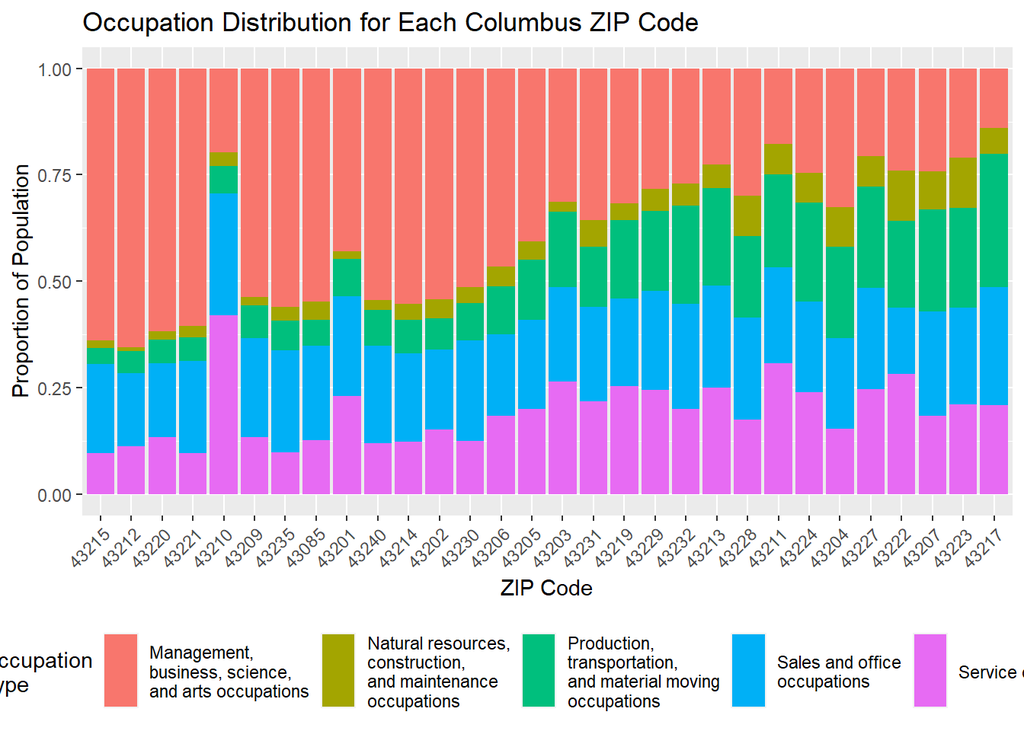

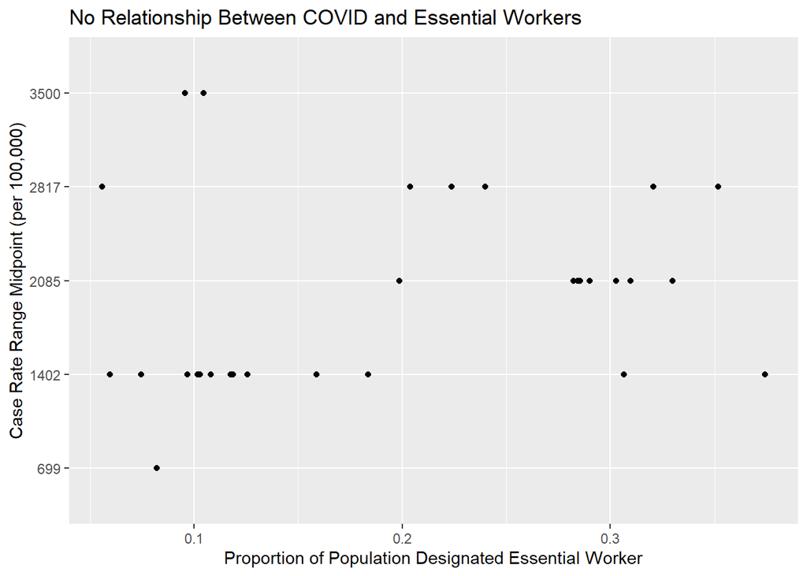

We can see from the scatterplot above that there doesn’t seem to be a relationship between the percentage of essential workers and the case rate of COVID. We can use Spearman’s correlation test, which allows for a comparison with the range of COVID case rates we have been given.

Our test gives a correlation value of $\rho=$ 0.2548 (with $p$-value 0.1666). With such a large $p$-value, this means that we’ve found no evidence of a relationship between the percentage of the population working “essential” jobs and the rate of COVID cases.

### Citizenship

The Census Bureau provides a distinction between different types of U.S. citizenship (e.g., naturalization, born in U.S., born abroad, etc.). We focus on the simple distinction between being a U.S. citizen and not.

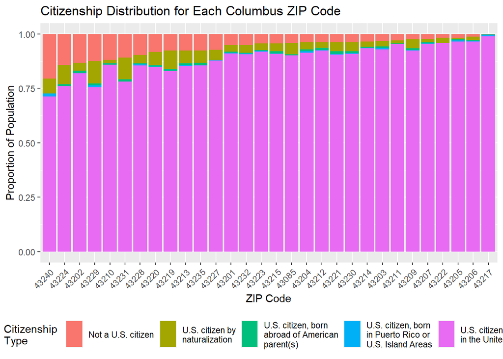

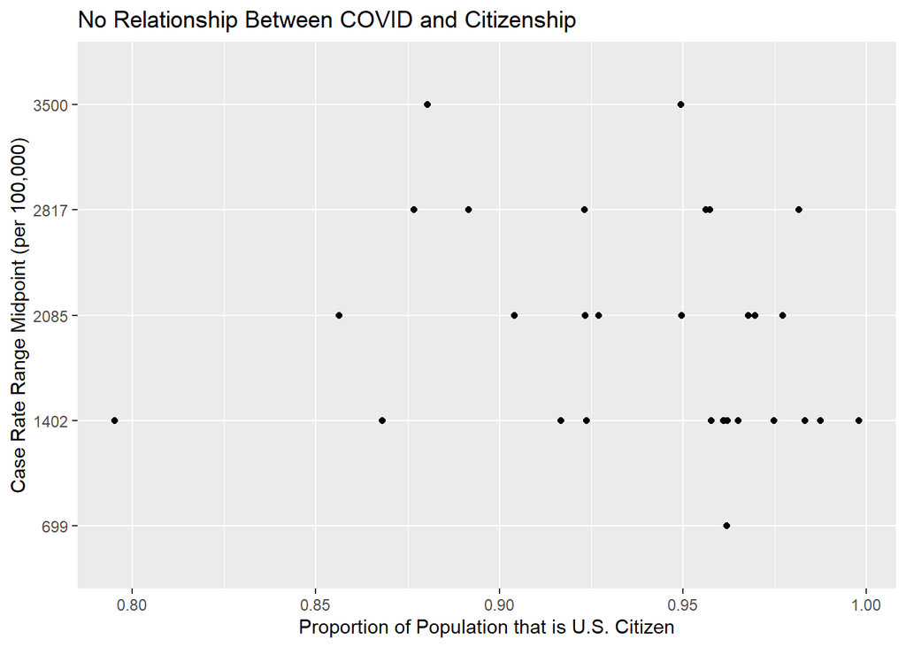

Our Spearman’s correlation test gives us a correlation value of $\rho=$ -0.3202 ($p=$ 0.0791). While this is a slight negative correlation value, our $p$-value is a bit too high to say with any confidence that there is a relationship here.

### Income

We look at the income data in increments designated by the Census Bureau. We calculated the proportion of people making over $100,000 to order the ZIP codes on the $x$-axis in the following graph.

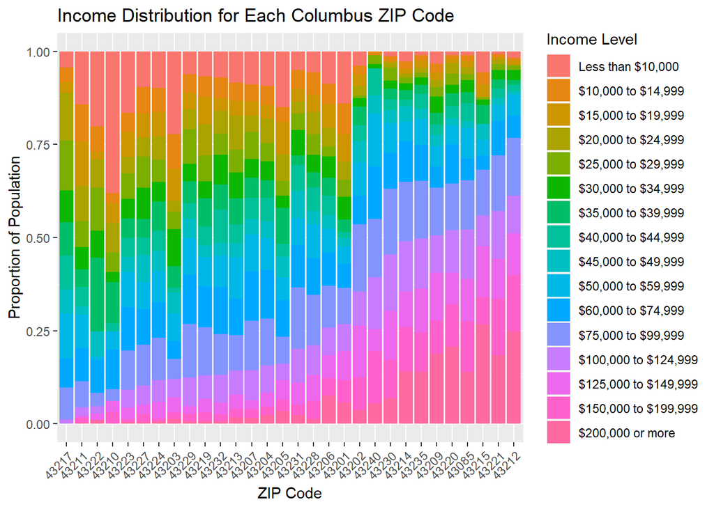

We see a nice distribution of six-figure incomes across the ZIP codes, ranging from just over 1% in ZIP 43217 all the way to over 61% of ZIP code 43212 making over $100,000.

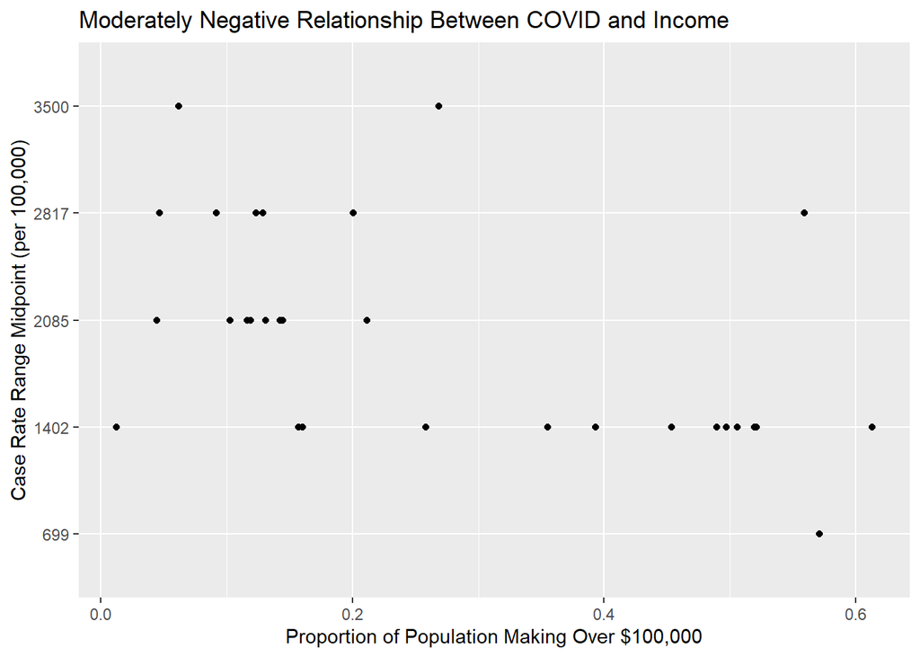

### Race

We have heard across the country that minorities are being impacted more by COVID. Does the data validate those statements here in Columbus, OH?

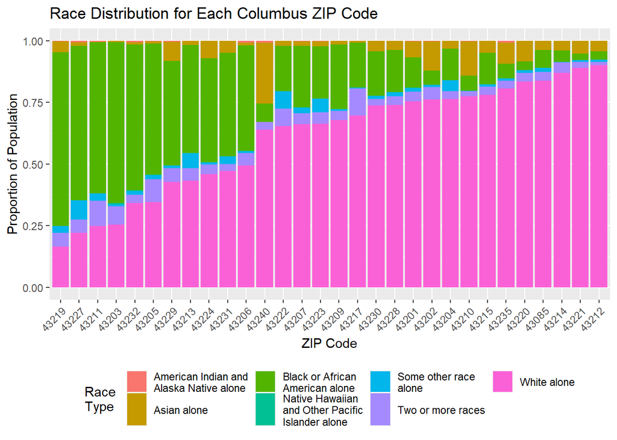

Analyzing our race graph, we see Black or African American individuals make up a large proportion of the about 1/3 of the ZIP codes. In the other parts of Columbus, white individuals make up most of the population. And there seems to be an inverse relationship, i.e., as the proportion of white people increase, the proportion of Black or African Americans decrease.

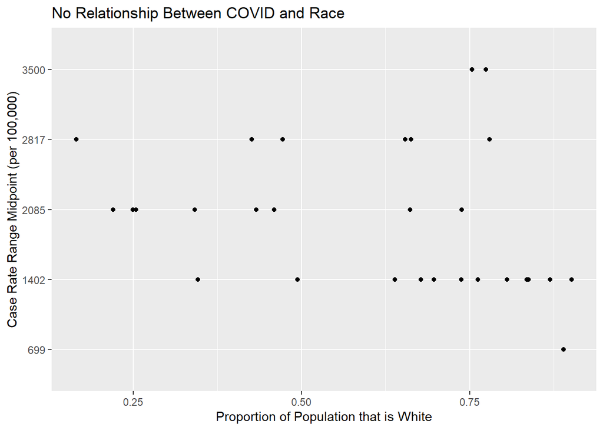

### Gini Index

The Gini index is a measure of income inequality calculated by the Census Bureau using various different factors. The closer to 0 the Gini index, the more equally income is dispersed. A Gini index of 1 would indicate perfect inequality where a single group or individual collects all of the income.

We can view a map of the Gini Index across Columbus ZIP codes:

[interactive chart not shown]

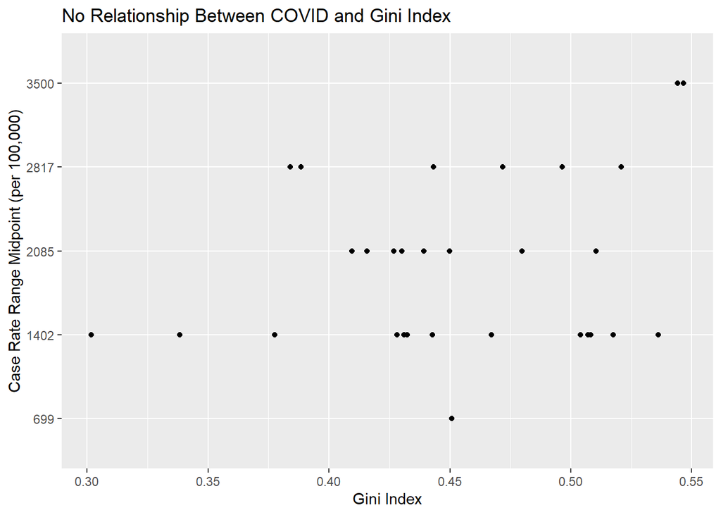

We see that no real pattern emerges between the Gini Index and COVID. This is supported by our statistical test ($\rho=$ 0.1651 with $p=$ 0.3747. The Gini Index is not correlated to the case rate of COVID.

### Insurance Coverage

Since access to private health insurance is not universal, we looked at the relationship between having some type of private health insurance and COVID as well as similarly looking at public health insurance. It is possible to have both public and private insurance, so these metrics are not mutually exclusive.

#### Private Health Insurance

We breakdown each ZIP code by the proportion of residents who have private health insurance.

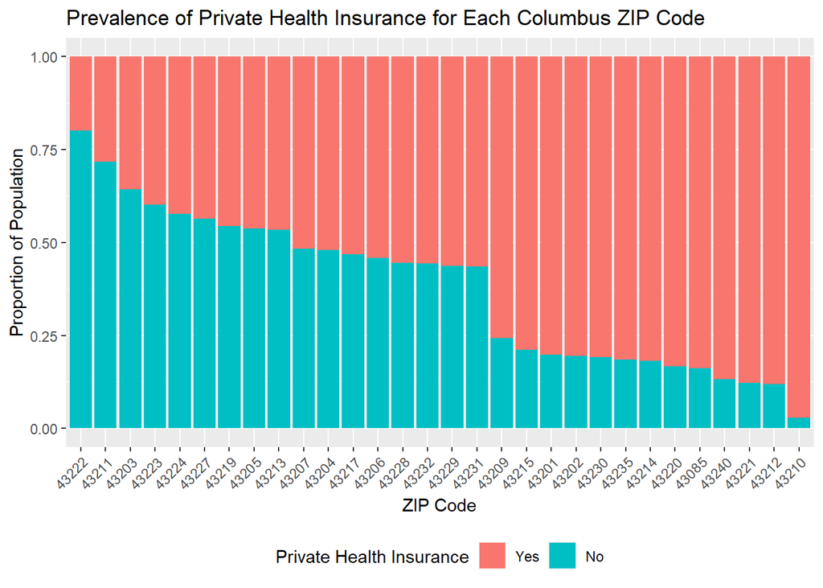

As we see, there is a wide range of those populations that have private health insurance, ranging from 97% of the population in 43210 to only 19% of the residents in 43222 having private health insurance. But how does this relate to COVID cases?

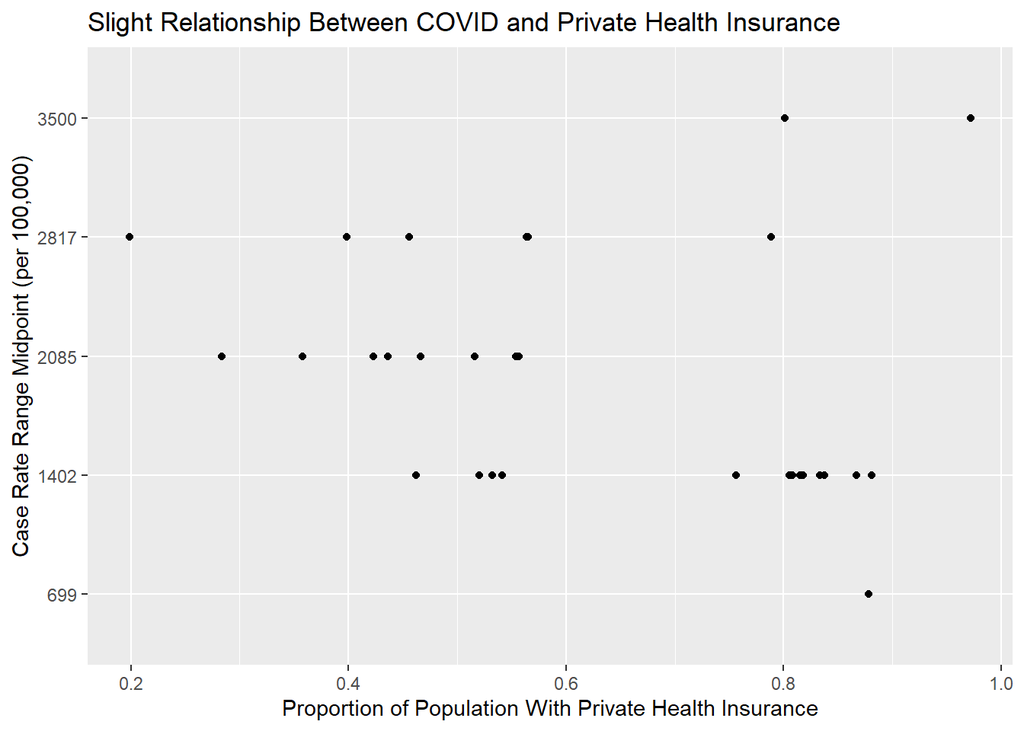

We do not see any obvious patterns in this relationship, however, after performing the Spearman’s rank correlation test, we see evidence to suggest a slight correlation with private health insurance. From the test we get a correlation value of $\rho=$ -0.3695 ($p=$ 0.0408). In this case, as the proportion of a ZIP code’s population that have private health insurance increases, we see a slight decrease in the case rate.

#### Public Health Insurance

We breakdown each ZIP code by the proportion of residents who have public health insurance.

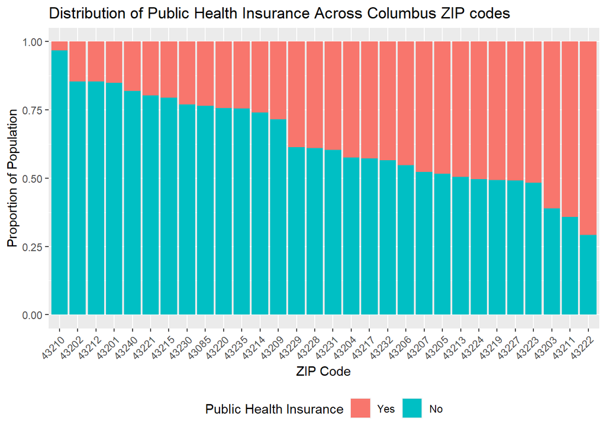

We still have a descent distinction between ZIP codes as to the proportion of their populations that have public insurance (ranges from 3% to 70%).

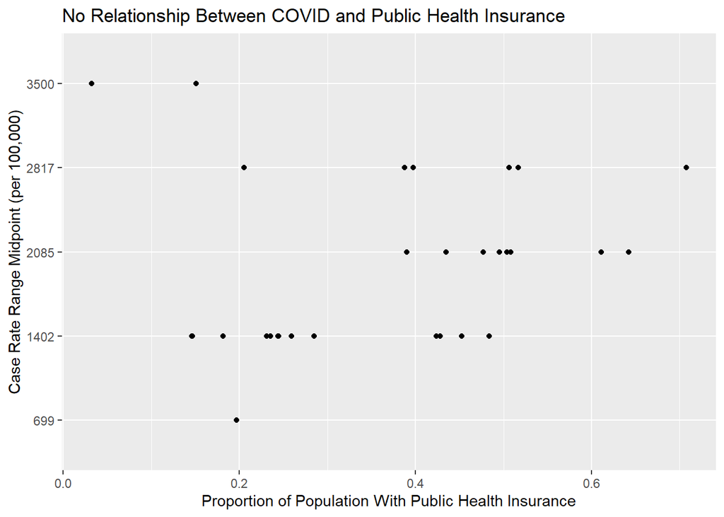

Our scatterplot does not show any relationship between these two variables. This remains true with our Spearman’s test with a high $p=$ 0.127, which means that our correlation value is indistinguishable from 0. We cannot detect any relationship here.

### Transportation to Work

The use of public transportation is more prevalent among lower incomes, while at the same time public transportation poses a higher risk of contracting COVID. We look to see if this idea plays out in the data for Columbus.

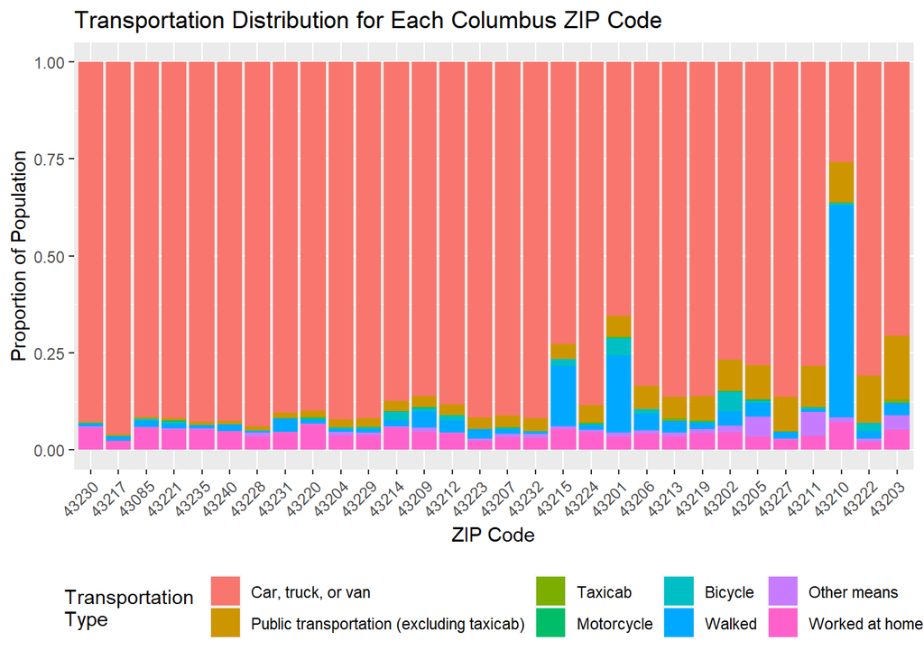

The percentage of the population that uses public transportation is not too high, never reaching above 17%. Most Columbus residents provide their own motorized transportation, while in a few ZIP codes walking and working from home is quite popular.

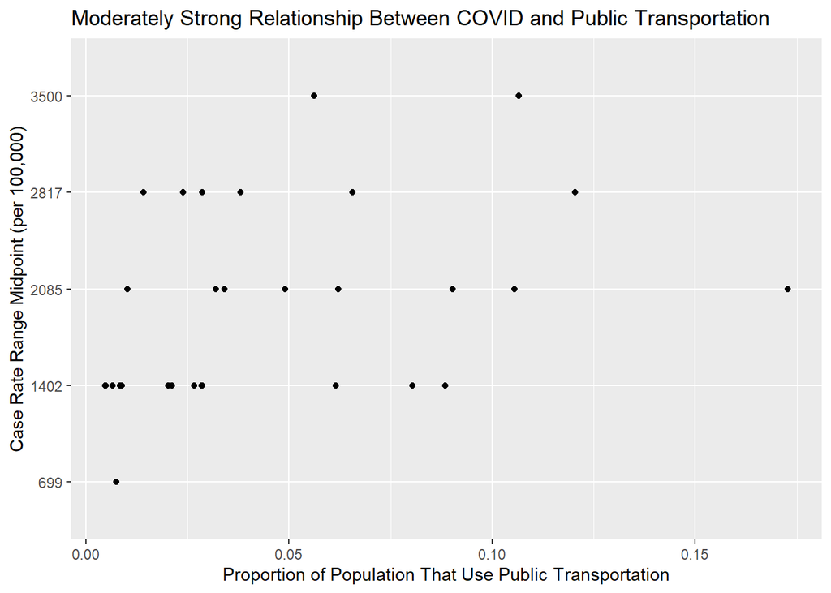

We see a moderate relationship between the use of public transportation and COVID. Conducting our tests gives us a correlation of $\rho=$ 0.5117 ($p=$ 0.0033). This is an overall moderate correlation and indicates that as a ZIP code had a higher use of public transportation, it is seeing a higher COVID rate now.